# Práctica 2: Limpieza y análisis de datos

Renán Freire, Manuel García

20/05/2021

# 1 Descripción del dataset

## 1.1 Descripción

Siguiendo la línea del deporte e inspirados en la película “Moneyball”, se ha encontrado un dataset llamado “Baseball Databank” (https://www.kaggle.com/open-source-sports/baseball-databank), que contiene una extensa base de datos sobre béisbol recopilada por el periodista Sean Lahman divididos en archivos planos (csv) y entre los más importantes se tiene:

- Master.csv: Contiene datos biográficos de los jugadores, como por ejemplo: Nombres, apellidos, lugar de nacimiento, año de nacimiento. Cada jugador tiene un identificado “playerID”.
- Batting.csv: Este archivo contiene datos estadísticos de bateo (corridas, homerun, número de golpes, etc).
- Pitching: Este archivo contiene datos estadísticos de lanzamiento (jugos ganados, perdidos, etc).
- Fielding.csv - Este archivo contiene datos estadísticos de las diferentes habilidades para moverse en el campo y atrapar, parar, lanzar, etc.
- Salaries.csv. Este archivo contiene el salario de cada jugador de acuerdo al año, equipo y liga jugada.

Cada registro de los datasets explicados están vinculado a un jugador mediante su identificador “playerID” además de otros identificadores relacionados a otros catálogos.

## 1.2 Importancia y Objetivo

Para esta práctica se ha centrado en el béisbol, debido a su importancia en el ámbito del BigData, ya que año tras año, este deporte genera gran cantidad de datos estadísticos en base a su complejidad, debido a sus diferentes reglas de juego y las diferentes características que cada jugador debe desempeñar de acuerdo a su posición en el campo de juego.

El objetivo para el cual usaremos los datos, está orientado a la predicción de los salarios de los bateadores y su dependencia con los datos de desempeño de cada jugador, generando modelos a través de algoritmos aprendizaje supervisado. Entre las preguntas a resolver tenemos:

- Se puedel explicar el salario de los jugadores con los atributos técnicos?
- Existe una diferencia significativa entre los salarios de los jugadores nacidos en USA y los jugadores del Resto del Mundo?
- Ha variado la proporción de jugadores nacidos en el Resto del Mundo con respecto a los nacidos en USA a lo largo de los últimos 10 años.

# 2 Integración y selección de los datos de interés a analizar.

## 2.1 Integración de fuentes de datos

De acuerdo al análisis del conjunto de datos y a la problemática a resolver, planteada para esta práctica, vamos a trabajar con los datos biográficos de los jugadores que juegan en la posición de bateadores además de sus datos estadísticos y su salario. Para esto vamos a realizar una fusión horizontal y vertical de los archivos: master.csv, batting.csv, salaries.csv; mediante los identificadores: “playerID” que relaciona cada fuente con el jugador y “yearID” vincula los años de los diferentes datos de rendimiento y el salario correspondiente.

```r
# Lectura de fuente de datos necesitadas
dataPlayer <- read.csv('../dataset/Master.csv')
print("[*] Dimensiones")
```

```
## [1] "[*] Dimensiones"
```

```r
dim(dataPlayer)
```

```
## [1] 18846    24
```

```r
print("[*] Nombre Columnas")
```

```
## [1] "[*] Nombre Columnas"
```

```r
colnames(dataPlayer)
```

```
##  [1] "playerID"     "birthYear"    "birthMonth"   "birthDay"     "birthCountry"
##  [6] "birthState"   "birthCity"    "deathYear"    "deathMonth"   "deathDay"
## [11] "deathCountry" "deathState"   "deathCity"    "nameFirst"    "nameLast"
## [16] "nameGiven"    "weight"       "height"       "bats"         "throws"
## [21] "debut"        "finalGame"    "retroID"      "bbrefID"
```

La fuente de datos **Master.csv** tiene las siguientes dimensiones: 18846 registros y 24 columnas.

```r
# Lectura de fuente de datos necesitadas
dataBatting <- read.csv('../dataset/Batting.csv')
print("[*] Dimensiones")
```

```
## [1] "[*] Dimensiones"
```

```r
dim(dataBatting)
```

```
## [1] 101332     22
```

```r
print("[*] Nombre Columnas")
```

```
## [1] "[*] Nombre Columnas"
```

```r
colnames(dataBatting)
```

```
##  [1] "playerID" "yearID"   "stint"    "teamID"   "lgID"     "G"
##  [7] "AB"       "R"        "H"        "X2B"      "X3B"      "HR"
## [13] "RBI"      "SB"       "CS"       "BB"       "SO"       "IBB"
## [19] "HBP"      "SH"       "SF"       "GIDP"
```

La fuente de datos **Batting.csv** tiene las siguientes dimensiones: 101332 registros y 22 columnas.

```r
# Lectura de fuente de datos necesitadas
dataSalaries <- read.csv('../dataset/Salaries.csv')
print("[*] Dimensiones")
```

```
## [1] "[*] Dimensiones"
```

```r
dim(dataSalaries)
```

```
## [1] 25575     5
```

```r
print("[*] Nombre Columnas")
```

```
## [1] "[*] Nombre Columnas"
```

```r
colnames(dataSalaries)
```

```
## [1] "yearID"   "teamID"   "lgID"     "playerID" "salary"
```

La fuente de datos **Salaries.csv** tiene las siguientes dimensiones: 25575 registros y 5 columnas.

```r
# Integración fuentes
mergeCols <- c("playerID", "yearID")

datasetBateadores <- merge(dataPlayer,dataSalaries,by="playerID")
datasetBateadores <- merge(dataBatting,datasetBateadores,by=mergeCols)
print("[*] Dimensiones")
```

```
## [1] "[*] Dimensiones"
```

```r
dim(datasetBateadores)
```

```
## [1] 27385    48
```

```r
print("[*] Nombre Columnas")
```

```
## [1] "[*] Nombre Columnas"
```

```r
colnames(datasetBateadores)
```

```
##  [1] "playerID"     "yearID"       "stint"        "teamID.x"     "lgID.x"
##  [6] "G"            "AB"           "R"            "H"            "X2B"
## [11] "X3B"          "HR"           "RBI"          "SB"           "CS"
## [16] "BB"           "SO"           "IBB"          "HBP"          "SH"
## [21] "SF"           "GIDP"         "birthYear"    "birthMonth"   "birthDay"
## [26] "birthCountry" "birthState"   "birthCity"    "deathYear"    "deathMonth"
## [31] "deathDay"     "deathCountry" "deathState"   "deathCity"    "nameFirst"
## [36] "nameLast"     "nameGiven"    "weight"       "height"       "bats"
## [41] "throws"       "debut"        "finalGame"    "retroID"      "bbrefID"
## [46] "teamID.y"     "lgID.y"       "salary"
```

El dataset final tiene las siguientes dimensiones: 27385 registros y 48 columnas.

```r
head(datasetBateadores)
```

```
##    playerID yearID stint teamID.x lgID.x  G AB R H X2B X3B HR RBI SB CS BB SO
## 1 aardsda01   2004     1      SFN     NL 11  0 0 0   0   0  0   0  0  0  0  0
## 2 aardsda01   2007     1      CHA     AL 25  0 0 0   0   0  0   0  0  0  0  0
## 3 aardsda01   2008     1      BOS     AL 47  1 0 0   0   0  0   0  0  0  0  1
## 4 aardsda01   2009     1      SEA     AL 73  0 0 0   0   0  0   0  0  0  0  0
## 5 aardsda01   2010     1      SEA     AL 53  0 0 0   0   0  0   0  0  0  0  0
## 6 aardsda01   2012     1      NYA     AL  1  0 0 0   0   0  0   0  0  0  0  0
##   IBB HBP SH SF GIDP birthYear birthMonth birthDay birthCountry birthState
## 1   0   0  0  0    0      1981         12       27          USA         CO
## 2   0   0  0  0    0      1981         12       27          USA         CO
## 3   0   0  0  0    0      1981         12       27          USA         CO
## 4   0   0  0  0    0      1981         12       27          USA         CO
## 5   0   0  0  0    0      1981         12       27          USA         CO
## 6   0   0  0  0    0      1981         12       27          USA         CO
##   birthCity deathYear deathMonth deathDay deathCountry deathState deathCity
```

[output cut: 20 more lines]

## 2.2 Selección de datos y reducción de dimensionalidad

Una vez analizado el dataset final, se puede identificar datos perdidos (N.D) para los años iniciales, por lo tanto, para nuestro objetivo, vamos a seleccionar todos los jugadores de posición bateadores correspondiente a los años 2014, 2015, siendo estos los datos más actuales disponibles y como resultado tenemos un conjunto de datos de alta calidad sin valores perdidos.

```r
# Selección de instancias de acuerdo a los anios 2014,2015
datasetBateadores.10 <- filter(datasetBateadores, yearID>=2005)
datasetBateadores.2005 <- filter(datasetBateadores, yearID==2005)
datasetBateadores <- filter(datasetBateadores, yearID>2013 & yearID<2016)
head(datasetBateadores)
```

```
##    playerID yearID stint teamID.x lgID.x   G  AB  R   H X2B X3B HR RBI SB CS BB
## 1  abadfe01   2014     1      OAK     AL  69   0  0   0   0   0  0   0  0  0  0
## 2  abadfe01   2015     1      OAK     AL  62   0  0   0   0   0  0   0  0  0  0
## 3 abreujo02   2014     1      CHA     AL 145 556 80 176  35   2 36 107  3  1 51
## 4 abreujo02   2015     1      CHA     AL 154 613 88 178  34   3 30 101  0  0 39
## 5 abreuto01   2014     1      SFN     NL   3   4  0   0   0   0  0   0  0  0  0
## 6 ackledu01   2014     1      SEA     AL 143 502 64 123  27   4 14  65  8  4 32
##    SO IBB HBP SH SF GIDP birthYear birthMonth birthDay birthCountry
## 1   0   0   0  0  0    0      1985         12       17         D.R.
## 2   0   0   0  0  0    0      1985         12       17         D.R.
## 3 131  15  11  0  4   14      1987          1       29         Cuba
## 4 140  11  15  0  1   16      1987          1       29         Cuba
## 5   0   0   0  0  0    1      1984         11       13         D.R.
## 6  90   1   3  3  2   10      1988          2       26          USA
##     birthState     birthCity deathYear deathMonth deathDay deathCountry
```

[output cut: 20 more lines]

Como se observa en la sección anterior, el dataset contiene una gran cantidad de atributos, por lo tanto aplicamos la técnica de selección de subconjuntos de atributos para seleccionar datos de interés. Primeramente los atributos correspondientes a los datos biográficos de cada jugar, seleccionaremos manualmente, identificando cuales son más relevantes para nuestro estudio *(yearID, playerID, nameFirst, nameLast, birthCountry, bats, birthYear, debut)*, ademas eliminaremos atributos de códigos *(stint, teamID.x, lgID.x)* que no tiene significado en nuestro análisis. Como resultado de esta selección tendremos el siguiente dataset:

```r
# Selección de atributos de interés de datos biográficos del jugador
datasetBateadores <-select(datasetBateadores, 'yearID','playerID','nameFirst', 'nameLast',
                           'birthCountry','bats','birthYear','debut','G', 'AB', 'R', 'H',
                           'X2B', 'X3B', 'HR', 'RBI', 'SB', 'CS', 'BB', 'SO', 'IBB', 'HBP',
                           'SH', 'SF', 'GIDP','salary');
head(datasetBateadores)
```

```
##   yearID  playerID nameFirst nameLast birthCountry bats birthYear      debut
## 1   2014  abadfe01  Fernando     Abad         D.R.    L      1985 2010-07-28
## 2   2015  abadfe01  Fernando     Abad         D.R.    L      1985 2010-07-28
## 3   2014 abreujo02      Jose    Abreu         Cuba    R      1987 2014-03-31
## 4   2015 abreujo02      Jose    Abreu         Cuba    R      1987 2014-03-31
## 5   2014 abreuto01      Tony    Abreu         D.R.    B      1984 2007-05-22
## 6   2014 ackledu01    Dustin   Ackley          USA    L      1988 2011-06-17
##     G  AB  R   H X2B X3B HR RBI SB CS BB  SO IBB HBP SH SF GIDP  salary
## 1  69   0  0   0   0   0  0   0  0  0  0   0   0   0  0  0    0  525900
## 2  62   0  0   0   0   0  0   0  0  0  0   0   0   0  0  0    0 1087500
## 3 145 556 80 176  35   2 36 107  3  1 51 131  15  11  0  4   14 7000000
## 4 154 613 88 178  34   3 30 101  0  0 39 140  11  15  0  1   16 8666000
## 5   3   4  0   0   0   0  0   0  0  0  0   0   0   0  0  0    1  745000
## 6 143 502 64 123  27   4 14  65  8  4 32  90   1   3  3  2   10 1700000
```

Los campos **birthYear** y **debut** son transformados a la edad del jugador de acuerdo al año de la observación y al número de años de experiencia del jugador respectivamente. Todo este proceso se presenta a continuación:

```r
# Transformar fecha debut en anios de experiencia
datasetBateadores$Exp<-datasetBateadores$yearID - as.numeric(format(as.Date(datasetBateadores$debut, format="%Y-%m-%d"),"%Y"))
# Transformar anio de nacimiento por edad
datasetBateadores$Edad<-datasetBateadores$yearID - datasetBateadores$birthYear
# Eliminamos columnas 'birthYear','debut'
datasetBateadores <- datasetBateadores[ -c(7:8) ]

head(datasetBateadores)
```

```
##   yearID  playerID nameFirst nameLast birthCountry bats   G  AB  R   H X2B X3B
## 1   2014  abadfe01  Fernando     Abad         D.R.    L  69   0  0   0   0   0
## 2   2015  abadfe01  Fernando     Abad         D.R.    L  62   0  0   0   0   0
## 3   2014 abreujo02      Jose    Abreu         Cuba    R 145 556 80 176  35   2
## 4   2015 abreujo02      Jose    Abreu         Cuba    R 154 613 88 178  34   3
## 5   2014 abreuto01      Tony    Abreu         D.R.    B   3   4  0   0   0   0
## 6   2014 ackledu01    Dustin   Ackley          USA    L 143 502 64 123  27   4
##   HR RBI SB CS BB  SO IBB HBP SH SF GIDP  salary Exp Edad
## 1  0   0  0  0  0   0   0   0  0  0    0  525900   4   29
## 2  0   0  0  0  0   0   0   0  0  0    0 1087500   5   30
## 3 36 107  3  1 51 131  15  11  0  4   14 7000000   0   27
## 4 30 101  0  0 39 140  11  15  0  1   16 8666000   1   28
## 5  0   0  0  0  0   0   0   0  0  0    1  745000   7   30
## 6 14  65  8  4 32  90   1   3  3  2   10 1700000   3   26
```

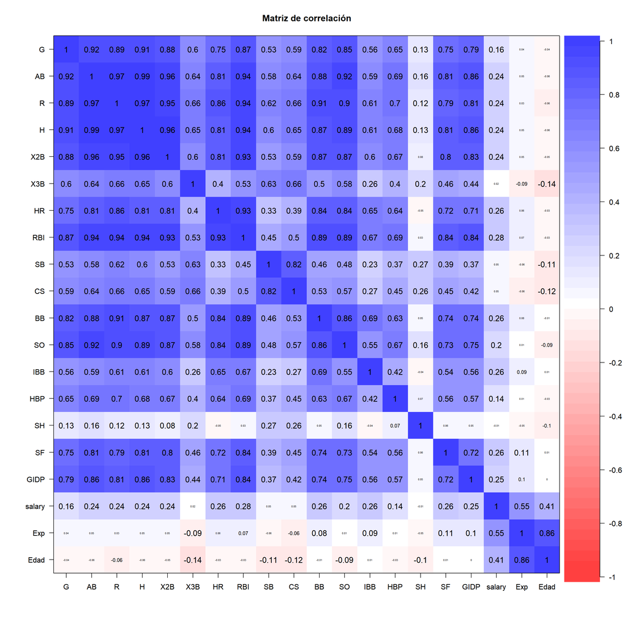

```r
library(psych)

corPlot(datasetBateadores[,7:26], cex = 0.7, main = "Matriz de correlación")
```

```r
# Selección de atributos de interés de datos de rendimiento
datasetBateadores <-select(datasetBateadores, 'yearID','playerID','nameFirst', 'nameLast',
                           'birthCountry','bats','Exp','G', 'X3B', 'HR', 'SB', 'CS', 'IBB',
                           'HBP', 'SH', 'SF', 'GIDP','salary');
head(datasetBateadores, n =10)
```

```
##    yearID  playerID nameFirst nameLast birthCountry bats Exp   G X3B HR SB CS
## 1    2014  abadfe01  Fernando     Abad         D.R.    L   4  69   0  0  0  0
## 2    2015  abadfe01  Fernando     Abad         D.R.    L   5  62   0  0  0  0
## 3    2014 abreujo02      Jose    Abreu         Cuba    R   0 145   2 36  3  1
## 4    2015 abreujo02      Jose    Abreu         Cuba    R   1 154   3 30  0  0
## 5    2014 abreuto01      Tony    Abreu         D.R.    B   7   3   0  0  0  0
## 6    2014 ackledu01    Dustin   Ackley          USA    L   3 143   4 14  8  4
## 7    2015 ackledu01    Dustin   Ackley          USA    L   4  23   2  4  0  0
## 8    2015 ackledu01    Dustin   Ackley          USA    L   4  85   1  6  2  2
## 9    2015 adamsau01    Austin    Adams          USA    R   1  28   0  0  0  0
## 10   2014 adamsma01      Matt    Adams          USA    L   2 142   5 15  3  2
##    IBB HBP SH SF GIDP  salary
## 1    0   0  0  0    0  525900
## 2    0   0  0  0    0 1087500
## 3   15  11  0  4   14 7000000
## 4   11  15  0  1   16 8666000
## 5    0   0  0  0    1  745000
## 6    1   3  3  2   10 1700000
## 7    0   0  0  1    0 2600000
## 8    0   1  3  3    3 2600000
## 9    0   0  0  0    1  507700
## 10   5   3  0  7    9  516000
```

A continuación, se va a detallar cada uno de los atributos que contiene el dataset final.

- yearID: Año de recopilación de datos de desempeño y salario.
- playerID: Identificador del jugador.
- nameFirst: Nombre del jugador.
- nameLast: Apellido del jugador.
- birthCountry: País de nacimiento del jugador.
- bats: Indica si el jugador es diestro o zurdo para coger el bat.
- exp: Anõs de experiencia desde su debut.
- G: Número de juegos a lo largo de la carrera.
- X3B: Número de veces que avanzó a tercera base el jugador.
- HR: Número de homerun.
- SB: Número de bases robadas por el jugador.
- CS: Número de eliminaciones por robar una base.
- IBB: Número de bases por bolas intencionales.
- HBP: Número de veces que fue golpeado por los lanzamientos de pitcher.
- SH: Números de sacrificios.
- SF: Número de elevados de sacrificio.
- GIDP: Núemero de Bateos para dobleplay.
- Salary: Salario anual del jugador.

Una vez realizado la selección de datos y la reducción de dimensionalidad, se ha descubierto que para ciertos jugadores del datastet tienen más de un registro para el mismo año, de acuerdo a la documentación de Sea Lahman, estos datos se presentan de esa forma ya que corresponden a los datos estadísticos de un jugador que estuvo en diferentes equipos o ligas para el mismo año. Para solucionar esto, se va a fusionar los registros de ese jugador en una sola fila y los datos estadísticos de rendimiento tendrán la suma de sus valores y para los años de experiencia y salario, como sus valores son iguales en los dos registros, solamente se escoge uno de ellos.

```r
# Se agrupan registros para el mismo jugador calculando la media de los datos estadisticos
datasetBateadores <- aggregate(cbind(G, X3B, HR, SB, CS, IBB, HBP, SH, SF, GIDP) ~ yearID
                               + playerID + nameFirst +  nameLast +  birthCountry + bats
                               + Exp + salary, data = datasetBateadores, FUN = sum)
# Ordenar por idJugador
datasetBateadores <- datasetBateadores[order(datasetBateadores$playerID),]
head(datasetBateadores, n=10)
```

```
##      yearID  playerID nameFirst nameLast birthCountry bats Exp  salary   G X3B
## 486    2014  abadfe01  Fernando     Abad         D.R.    L   4  525900  69   0
## 699    2015  abadfe01  Fernando     Abad         D.R.    L   5 1087500  62   0
## 1266   2014 abreujo02      Jose    Abreu         Cuba    R   0 7000000 145   2
## 1349   2015 abreujo02      Jose    Abreu         Cuba    R   1 8666000 154   3
## 597    2014 abreuto01      Tony    Abreu         D.R.    B   7  745000   3   0
## 811    2014 ackledu01    Dustin   Ackley          USA    L   3 1700000 143   4
## 951    2015 ackledu01    Dustin   Ackley          USA    L   4 2600000 108   3
## 177    2015 adamsau01    Austin    Adams          USA    R   1  507700  28   0
## 378    2014 adamsma01      Matt    Adams          USA    L   2  516000 142   5
## 521    2015 adamsma01      Matt    Adams          USA    L   3  534000  60   0
##      HR SB CS IBB HBP SH SF GIDP
## 486   0  0  0   0   0  0  0    0
## 699   0  0  0   0   0  0  0    0
## 1266 36  3  1  15  11  0  4   14
## 1349 30  0  0  11  15  0  1   16
## 597   0  0  0   0   0  0  0    1
## 811  14  8  4   1   3  3  2   10
## 951  10  2  2   0   1  3  4    3
## 177   0  0  0   0   0  0  0    1
## 378  15  3  2   5   3  0  7    9
## 521   5  1  0   1   0  0  1    1
```

## 2.3 Tipos de variables

Después de haber seleccionado las observaciones y los atributos para el conjunto de datos a trabajar, se verificará los tipos de datos de las diferentes columnas que conforman en el dataset, mediante la función de R **str()**, como se ve a continuación:

```r
str(datasetBateadores)
```

```
## 'data.frame':    1609 obs. of  18 variables:
##  $ yearID      : int  2014 2015 2014 2015 2014 2014 2015 2015 2014 2015 ...
##  $ playerID    : chr  "abadfe01" "abadfe01" "abreujo02" "abreujo02" ...
##  $ nameFirst   : chr  "Fernando" "Fernando" "Jose" "Jose" ...
##  $ nameLast    : chr  "Abad" "Abad" "Abreu" "Abreu" ...
##  $ birthCountry: chr  "D.R." "D.R." "Cuba" "Cuba" ...
##  $ bats        : chr  "L" "L" "R" "R" ...
##  $ Exp         : num  4 5 0 1 7 3 4 1 2 3 ...
##  $ salary      : int  525900 1087500 7000000 8666000 745000 1700000 2600000 507700 516000 534000 ...
##  $ G           : int  69 62 145 154 3 143 108 28 142 60 ...
##  $ X3B         : int  0 0 2 3 0 4 3 0 5 0 ...
##  $ HR          : int  0 0 36 30 0 14 10 0 15 5 ...
##  $ SB          : int  0 0 3 0 0 8 2 0 3 1 ...
##  $ CS          : int  0 0 1 0 0 4 2 0 2 0 ...
##  $ IBB         : int  0 0 15 11 0 1 0 0 5 1 ...
##  $ HBP         : int  0 0 11 15 0 3 1 0 3 0 ...
##  $ SH          : int  0 0 0 0 0 3 3 0 0 0 ...
##  $ SF          : int  0 0 4 1 0 2 4 0 7 1 ...
##  $ GIDP        : int  0 0 14 16 1 10 3 1 9 1 ...
```

De acuerdo a la salida de esta función, tenemos que los datos de rendimimento que se van a analizar son de tipo entero, listos para los análisis posteriores. Solo la variable Exp será trasformada de numérica a entera.

```r
datasetBateadores$Exp <- as.integer(datasetBateadores$Exp)
head(datasetBateadores, n=10)
```

```
##      yearID  playerID nameFirst nameLast birthCountry bats Exp  salary   G X3B
## 486    2014  abadfe01  Fernando     Abad         D.R.    L   4  525900  69   0
## 699    2015  abadfe01  Fernando     Abad         D.R.    L   5 1087500  62   0
## 1266   2014 abreujo02      Jose    Abreu         Cuba    R   0 7000000 145   2
## 1349   2015 abreujo02      Jose    Abreu         Cuba    R   1 8666000 154   3
## 597    2014 abreuto01      Tony    Abreu         D.R.    B   7  745000   3   0
## 811    2014 ackledu01    Dustin   Ackley          USA    L   3 1700000 143   4
## 951    2015 ackledu01    Dustin   Ackley          USA    L   4 2600000 108   3
## 177    2015 adamsau01    Austin    Adams          USA    R   1  507700  28   0
## 378    2014 adamsma01      Matt    Adams          USA    L   2  516000 142   5
## 521    2015 adamsma01      Matt    Adams          USA    L   3  534000  60   0
##      HR SB CS IBB HBP SH SF GIDP
## 486   0  0  0   0   0  0  0    0
## 699   0  0  0   0   0  0  0    0
## 1266 36  3  1  15  11  0  4   14
## 1349 30  0  0  11  15  0  1   16
## 597   0  0  0   0   0  0  0    1
## 811  14  8  4   1   3  3  2   10
## 951  10  2  2   0   1  3  4    3
## 177   0  0  0   0   0  0  0    1
## 378  15  3  2   5   3  0  7    9
## 521   5  1  0   1   0  0  1    1
```

# 3 Limpieza de datos

## 3.1 Detección y tratamiento de valores perdidos

EL dataset final, no contiene datos perdidos o no definidos ya que en secciones anteriores se filtraron los datos para los años mas actuales debido a que los años más antiguos tenían un gran porcentaje de datos no definidos.

```r
# Valores perdidos determinados por N.A
colSums(is.na(datasetBateadores))
```

```
##       yearID     playerID    nameFirst     nameLast birthCountry         bats
##            0            0            0            0            0            0
##          Exp       salary            G          X3B           HR           SB
##            0            0            0            0            0            0
##           CS          IBB          HBP           SH           SF         GIDP
##            0            0            0            0            0            0
```

Sin embargo, después de realizar una inspección al conjunto de datos, se ha identificado un caso especial, donde existen registros con valor 0 en las variables de rendimiento **X3B, HR, SB, CS, IBB, HBP, SH, SF, GIDP** y la variable salario posse un valor. Este caso es un problema, debido a que una de nuestras preguntas iniciales consisten en determinar la relación del las variables de rendimiento con el valor del salario del jugador. Para solucionar esto, se va a implementar un proceso de imputación para estos valores 0 de todas las variables antes mencionadas mediante el algoritmo del vecino más cercano KNN.

El proceso consiste en los siguientes pasos:

- Asignar el valor *NA* a las variables de rendimiento con valor 0 cuyos registros cumplan la condición: X3B == 0 & HR == 0 & SB == 0 & CS == 0 & IBB == 0 & HBP == 0 & SH == 0 & SF == 0 & GIDP == 0.
- Imputación de valores *NA* haciendo uso del modelo KNN, rellenando los valores *NA*, en base a las demás observaciones del dataset, promediando todos los puntos más cercanos.

Esta implementación se puede observar a continuación, que consta de la identificación del número de casos con datos de rendimiento en 0, además se inspeccionan las variables salario y G para ver si poseen valores en 0 y finalmente la inputación de valores de acuerdo a lo panteado.

```r
# Verificamos datos de salario en 0
dfSalarioCero <- filter(datasetBateadores, salary==0)

# Verificamos datos de G en 0
dfGCero <- filter(datasetBateadores, G==0)


# Verificamos datos de rendimiento en 0
dfEstadisticasCero <- filter(datasetBateadores, X3B == 0 & HR == 0 & SB == 0 & CS == 0 & IBB == 0 & HBP == 0 & SH == 0 & SF == 0 & GIDP == 0 )

# cosntruye dataframe de resultados
resultados <-data.frame(c(nrow(dfEstadisticasCero), nrow(dfSalarioCero), nrow(dfGCero)),
                        c('DATOS RENDIMIENTO EN 0', 'DATOS SALARIOS EN 0', 'DATOS G EN 0'))
resultados <- setNames(resultados, c('Nro. Registros', 'Descripción'))
resultados
```

```
##   Nro. Registros            Descripción
## 1            555 DATOS RENDIMIENTO EN 0
## 2              0    DATOS SALARIOS EN 0
## 3              0           DATOS G EN 0
```

```r
# Obtener indices de los datos de rendimiento tengan todos 0
indicesFiltros <- which(datasetBateadores$X3B == 0 & datasetBateadores$HR == 0 &
                          datasetBateadores$SB == 0 & datasetBateadores$CS == 0 &
                          datasetBateadores$IBB == 0 & datasetBateadores$HBP == 0 &
                          datasetBateadores$SH == 0 & datasetBateadores$SF == 0 &
                          datasetBateadores$GIDP == 0)
# Reemplazar valores de 0 por NA para los indices extraídos
datasetBateadores$X3B[indicesFiltros] <- NA
datasetBateadores$HR[indicesFiltros] <- NA
datasetBateadores$SB[indicesFiltros] <- NA
datasetBateadores$CS[indicesFiltros] <- NA
datasetBateadores$IBB[indicesFiltros] <- NA
datasetBateadores$HBP[indicesFiltros] <- NA
datasetBateadores$SH[indicesFiltros] <- NA
datasetBateadores$SF[indicesFiltros] <- NA
datasetBateadores$GIDP[indicesFiltros] <- NA
# Verificamos valores NA
colSums(is.na(datasetBateadores))
```

```
##       yearID     playerID    nameFirst     nameLast birthCountry         bats
##            0            0            0            0            0            0
##          Exp       salary            G          X3B           HR           SB
##            0            0            0          555          555          555
##           CS          IBB          HBP           SH           SF         GIDP
##          555          555          555          555          555          555
```

```r
# Imputación de valores perdidos
datasetBateadores <- kNN(datasetBateadores)
head(datasetBateadores,n=10)
```

```
##    yearID  playerID nameFirst nameLast birthCountry bats Exp  salary   G X3B HR
## 1    2014  abadfe01  Fernando     Abad         D.R.    L   4  525900  69   3  3
## 2    2015  abadfe01  Fernando     Abad         D.R.    L   5 1087500  62   3 17
## 3    2014 abreujo02      Jose    Abreu         Cuba    R   0 7000000 145   2 36
## 4    2015 abreujo02      Jose    Abreu         Cuba    R   1 8666000 154   3 30
## 5    2014 abreuto01      Tony    Abreu         D.R.    B   7  745000   3   0  0
## 6    2014 ackledu01    Dustin   Ackley          USA    L   3 1700000 143   4 14
## 7    2015 ackledu01    Dustin   Ackley          USA    L   4 2600000 108   3 10
## 8    2015 adamsau01    Austin    Adams          USA    R   1  507700  28   0  0
## 9    2014 adamsma01      Matt    Adams          USA    L   2  516000 142   5 15
## 10   2015 adamsma01      Matt    Adams          USA    L   3  534000  60   0  5
##    SB CS IBB HBP SH SF GIDP yearID_imp playerID_imp nameFirst_imp nameLast_imp
## 1   6  3   5   1  0  2    3      FALSE        FALSE         FALSE        FALSE
## 2   1  2   6   2  0  3    8      FALSE        FALSE         FALSE        FALSE
## 3   3  1  15  11  0  4   14      FALSE        FALSE         FALSE        FALSE
```

[output cut: 29 more lines]

La función utilizada para imputar valores adiciona al dataset unas nuevas columnas de tipo booleanas indicando true o false para el proceso KNN. Por lo tanto, eliminaremos estas columnas de nuestra dataset final.

```r
# Eliminar columnas agregagdas por el método KNN usado para imputación
datasetBateadores <- datasetBateadores[ -c(19:36) ]
head(datasetBateadores, n=10)
```

```
##    yearID  playerID nameFirst nameLast birthCountry bats Exp  salary   G X3B HR
## 1    2014  abadfe01  Fernando     Abad         D.R.    L   4  525900  69   3  3
## 2    2015  abadfe01  Fernando     Abad         D.R.    L   5 1087500  62   3 17
## 3    2014 abreujo02      Jose    Abreu         Cuba    R   0 7000000 145   2 36
## 4    2015 abreujo02      Jose    Abreu         Cuba    R   1 8666000 154   3 30
## 5    2014 abreuto01      Tony    Abreu         D.R.    B   7  745000   3   0  0
## 6    2014 ackledu01    Dustin   Ackley          USA    L   3 1700000 143   4 14
## 7    2015 ackledu01    Dustin   Ackley          USA    L   4 2600000 108   3 10
## 8    2015 adamsau01    Austin    Adams          USA    R   1  507700  28   0  0
## 9    2014 adamsma01      Matt    Adams          USA    L   2  516000 142   5 15
## 10   2015 adamsma01      Matt    Adams          USA    L   3  534000  60   0  5
##    SB CS IBB HBP SH SF GIDP
## 1   6  3   5   1  0  2    3
## 2   1  2   6   2  0  3    8
## 3   3  1  15  11  0  4   14
## 4   0  0  11  15  0  1   16
## 5   0  0   0   0  0  0    1
## 6   8  4   1   3  3  2   10
## 7   2  2   0   1  3  4    3
## 8   0  0   0   0  0  0    1
## 9   3  2   5   3  0  7    9
## 10  1  0   1   0  0  1    1
```

## 3.2 Identificación y tratamiento de valores extremos.

Para nuestro dataset final vamos a identificar si existen valores extremos sobre las variables de tipo numérico, mediante gráficas de caja y bigote para cada variable implicada. A continuación se presentan las gŕaficas y los resultados obtenidos.

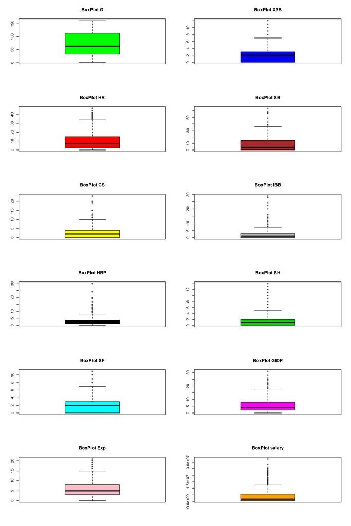

```r
par(mfrow=c(6,2))
boxplot(datasetBateadores$G, main="BoxPlot G", col="green")
outliersG <- boxplot.stats(datasetBateadores$G)$out

boxplot(datasetBateadores$X3B, main="BoxPlot X3B", col="blue")
outliersX3B <- boxplot.stats(datasetBateadores$X3B)$out

boxplot(datasetBateadores$HR, main="BoxPlot HR", col="red")
outliersHR <- boxplot.stats(datasetBateadores$HR)$out

boxplot(datasetBateadores$SB, main="BoxPlot SB", col="brown")
outliersSB <- boxplot.stats(datasetBateadores$SB)$out

boxplot(datasetBateadores$CS, main="BoxPlot CS", col="yellow")
outliersCS <- boxplot.stats(datasetBateadores$CS)$out

boxplot(datasetBateadores$IBB, main="BoxPlot IBB", col="gray")
outliersIBB <- boxplot.stats(datasetBateadores$IBB)$out

boxplot(datasetBateadores$HBP, main="BoxPlot HBP", col="black")
outliersHBP <- boxplot.stats(datasetBateadores$HBP)$out

boxplot(datasetBateadores$SH, main="BoxPlot SH", col="green3")
outliersSH <- boxplot.stats(datasetBateadores$SH)$out

boxplot(datasetBateadores$SF, main="BoxPlot SF", col="cyan")
outliersSF <- boxplot.stats(datasetBateadores$SF)$out

boxplot(datasetBateadores$GIDP, main="BoxPlot GIDP", col="magenta")
outliersGIDP <- boxplot.stats(datasetBateadores$GIDP)$out

boxplot(datasetBateadores$Exp, main="BoxPlot Exp", col="pink")
outliersExp <- boxplot.stats(datasetBateadores$Exp)$out

boxplot(datasetBateadores$salary, main="BoxPlot salary", col="orange")
```

```r
outlierssalary <- boxplot.stats(datasetBateadores$salary)$out
```

De acuerdo a los gráficos, podemos identificar el número de valores atípicos para cada atributo.

```r
resultadosOutliersDF <-data.frame(c(length(outliersG),
                                    length(outliersX3B),
                                    length(outliersHR),
                                    length(outliersSB),
                                    length(outliersCS),
                                    length(outliersIBB),
                                    length(outliersHBP),
                                    length(outliersSH),
                                    length(outliersSF),
                                    length(outliersGIDP),
                                    length(outliersExp),
                                    length(outlierssalary)
                                    ),
                        c('VARIABLE G',
                          'VARIABLE X3B',
                          'VARIABLE HR',
                          'VARIABLE SB',
                          'VARIABLE CS',
                          'VARIABLE IBB',
                          'VARIABLE HBP',
                          'VARIABLE SH',
                          'VARIABLE SF',
                          'VARIABLE GIDP',
                          'VARIABLE Exp',
                          'VARIABLE salary'
                          )
                        )
resultadosOutliersDF <- setNames(resultadosOutliersDF, c('Nro. Valores Atípicos', 'Variable'))
resultadosOutliersDF
```

```
##    Nro. Valores Atípicos        Variable
## 1                      0      VARIABLE G
## 2                     30    VARIABLE X3B
## 3                     22     VARIABLE HR
## 4                     10     VARIABLE SB
## 5                     11     VARIABLE CS
## 6                     60    VARIABLE IBB
## 7                     69    VARIABLE HBP
## 8                    119     VARIABLE SH
## 9                     39     VARIABLE SF
## 10                    66   VARIABLE GIDP
## 11                    27    VARIABLE Exp
## 12                   146 VARIABLE salary
```

El tratamiento que hemos decidido realizar sobre los valores atípicos es la eliminación de las observaciones que contengan esos valores. Se ha tomado esta decisión para evitar sesgos dentro de nuestro análisis, ya que este se basa directamente sobres estas variables. El proceso es implementado a continuación.

```r
# reemplazo de outliers con NA  y posterior eliminación
outliersReplace <- function(vectorOutliers, data){
  for (val in vectorOutliers)
  {
    data[data==val] <- NA
  }
  data
}

datasetBateadores$X3B <- outliersReplace(outliersX3B, datasetBateadores$X3B)
datasetBateadores$HR <- outliersReplace(outliersHR, datasetBateadores$HR)
datasetBateadores$SB <- outliersReplace(outliersSB, datasetBateadores$SB)
datasetBateadores$CS <- outliersReplace(outliersCS, datasetBateadores$CS)
datasetBateadores$IBB <- outliersReplace(outliersIBB, datasetBateadores$IBB)
datasetBateadores$HBP <- outliersReplace(outliersHBP, datasetBateadores$HBP)
datasetBateadores$SH <- outliersReplace(outliersSH, datasetBateadores$SH)
datasetBateadores$SF <- outliersReplace(outliersSF, datasetBateadores$SF)
datasetBateadores$GIDP <- outliersReplace(outliersGIDP, datasetBateadores$GIDP)
datasetBateadores$Exp <- outliersReplace(outliersExp, datasetBateadores$Exp)
datasetBateadores$salary <- outliersReplace(outlierssalary, datasetBateadores$salary)

datasetBateadores <- na.omit(datasetBateadores)
```

Con esto hemos concluido con la fase de pre-procesamiento de los datos. A continuación se examina la dimensión total del dataset final.

```r
# Dimension final del dataset
dim(datasetBateadores)
```

```
## [1] 1185   18
```

# 4 Análisis de los datos.

```r
datasetBateadores <- filter(datasetBateadores, yearID==2015)

head(datasetBateadores)
```

```
##   yearID  playerID nameFirst nameLast birthCountry bats Exp  salary   G X3B HR
## 1   2015  abadfe01  Fernando     Abad         D.R.    L   5 1087500  62   3 17
## 2   2015 ackledu01    Dustin   Ackley          USA    L   4 2600000 108   3 10
## 3   2015 adamsau01    Austin    Adams          USA    R   1  507700  28   0  0
## 4   2015 adamsma01      Matt    Adams          USA    L   3  534000  60   0  5
## 5   2015 affelje01    Jeremy  Affeldt          USA    L  13 6000000  52   3 15
## 6   2015 ahmedni01      Nick    Ahmed          USA    R   1  508500 134   6  9
##   SB CS IBB HBP SH SF GIDP
## 1  1  2   6   2  0  3    8
## 2  2  2   0   1  3  4    3
## 3  0  0   0   0  0  0    1
## 4  1  0   1   0  0  1    1
## 5  4  2   1   0  1  1    1
## 6  4  5   1   1  5  3    4
```

```r
str(datasetBateadores)
```

```
## 'data.frame':    601 obs. of  18 variables:
##  $ yearID      : int  2015 2015 2015 2015 2015 2015 2015 2015 2015 2015 ...
##  $ playerID    : chr  "abadfe01" "ackledu01" "adamsau01" "adamsma01" ...
##  $ nameFirst   : chr  "Fernando" "Dustin" "Austin" "Matt" ...
##  $ nameLast    : chr  "Abad" "Ackley" "Adams" "Adams" ...
##  $ birthCountry: chr  "D.R." "USA" "USA" "USA" ...
##  $ bats        : chr  "L" "L" "R" "L" ...
##  $ Exp         : int  5 4 1 3 13 1 9 4 1 3 ...
##  $ salary      : int  1087500 2600000 507700 534000 6000000 508500 1500000 1725000 510000 547100 ...
##  $ G           : int  62 108 28 60 52 134 30 67 11 70 ...
##  $ X3B         : int  3 3 0 0 3 6 3 2 0 4 ...
##  $ HR          : int  17 10 0 5 15 9 17 15 0 20 ...
##  $ SB          : int  1 2 0 1 4 4 6 21 1 21 ...
##  $ CS          : int  2 2 0 0 2 5 2 5 0 5 ...
##  $ IBB         : int  6 0 0 1 1 1 6 2 0 1 ...
##  $ HBP         : int  2 1 0 0 0 1 2 5 0 2 ...
##  $ SH          : int  0 3 0 0 1 5 1 1 1 1 ...
##  $ SF          : int  3 4 0 1 1 3 3 2 0 2 ...
##  $ GIDP        : int  8 3 1 1 1 4 3 7 0 4 ...
##  - attr(*, "na.action")= 'omit' Named int [1:424] 3 4 26 27 28 32 34 37 38 40 ...
##   ..- attr(*, "names")= chr [1:424] "3" "4" "26" "27" ...
```

## 4.1 Selección de los grupos de datos que se quieren analizar/comparar (planificación de los análisis a aplicar).

```r
library(psych)

#head(datasetBateadores)
#str(datasetBateadores)

# Creamos las muestras de jugadores de USA y RM para 2015
bat.usa <-datasetBateadores %>%
  filter(birthCountry =='USA')
bat.rm <-datasetBateadores %>%
  filter(birthCountry !='USA')

# Creamos las muestras de jugadores de USA y RM para 2005
bat.usa.2005 <-datasetBateadores.2005 %>%
  filter(birthCountry =='USA')
bat.rm.2005 <-datasetBateadores.2005 %>%
  filter(birthCountry !='USA')


# dimensiones

dim(bat.usa)
```

```
## [1] 438  18
```

```r
dim(bat.rm)
```

```
## [1] 163  18
```

```r
# Vista de los datos

head(bat.usa)
```

```
##   yearID  playerID nameFirst nameLast birthCountry bats Exp  salary   G X3B HR
## 1   2015 ackledu01    Dustin   Ackley          USA    L   4 2600000 108   3 10
## 2   2015 adamsau01    Austin    Adams          USA    R   1  507700  28   0  0
## 3   2015 adamsma01      Matt    Adams          USA    L   3  534000  60   0  5
## 4   2015 affelje01    Jeremy  Affeldt          USA    L  13 6000000  52   3 15
## 5   2015 ahmedni01      Nick    Ahmed          USA    R   1  508500 134   6  9
## 6   2015 alberma01      Matt   Albers          USA    L   9 1500000  30   3 17
##   SB CS IBB HBP SH SF GIDP
## 1  2  2   0   1  3  4    3
## 2  0  0   0   0  0  0    1
## 3  1  0   1   0  0  1    1
## 4  4  2   1   0  1  1    1
## 5  4  5   1   1  5  3    4
## 6  6  2   6   2  1  3    3
```

```r
head(bat.rm)
```

```
##   yearID  playerID nameFirst     nameLast birthCountry bats Exp  salary   G X3B
## 1   2015  abadfe01  Fernando         Abad         D.R.    L   5 1087500  62   3
## 2   2015 albural01        Al Alburquerque         D.R.    R   4 1725000  67   2
## 3   2015 alcanar01 Arismendy    Alcantara         D.R.    B   1  510000  11   0
## 4   2015 alonsyo01    Yonder       Alonso         Cuba    L   5 1650000 103   1
## 5   2015 alvarhe01 Henderson      Alvarez    Venezuela    R   4 4000000   4   2
## 6   2015 alvarjo02      Jose      Alvarez    Venezuela    L   2  509500  64   3
##   HR SB CS IBB HBP SH SF GIDP
## 1 17  1  2   6   2  0  3    8
## 2 15 21  5   2   5  1  2    7
## 3  0  1  0   0   0  1  0    0
## 4  5  2  5   3   3  0  3   13
## 5 19 25  9   3   4  1  1    7
## 6 15 15  4   1   2  1  0    3
```

```r
# dimensiones 2005

dim(bat.usa.2005)
```

```
## [1] 616  48
```

```r
dim(bat.rm.2005)
```

```
## [1] 264  48
```

```r
# Vista de los datos 2005

head(bat.usa.2005)
```

```
##    playerID yearID stint teamID.x lgID.x   G  AB  R   H X2B X3B HR RBI SB CS BB
## 1 adamsmi03   2005     1      MIL     NL  13   0  0   0   0   0  0   0  0  0  0
## 2 adamsru01   2005     1      TOR     AL 139 481 68 123  27   5  8  63 11  2 50
## 3 adamste01   2005     1      PHI     NL  16   0  0   0   0   0  0   0  0  0  0
## 4 affelje01   2005     1      KCA     AL  49   0  0   0   0   0  0   0  0  0  0
## 5 aguilch01   2005     1      FLO     NL  65  78 11  19   3   0  0   4  0  1  3
## 6 allench01   2005     1      TEX     AL  21  53  5  15   1   1  0   5  0  1  2
##   SO IBB HBP SH SF GIDP birthYear birthMonth birthDay birthCountry birthState
## 1  0   0   0  0  0    0      1978          7       29          USA         TX
## 2 57   1   3  3  8    5      1980          8       30          USA         NC
## 3  0   0   0  0  0    0      1973          3        6          USA         AL
## 4  0   0   0  0  0    0      1979          6        6          USA         AZ
## 5 19   0   0  0  0    0      1979          2       23          USA         CA
## 6 13   0   0  1  0    2      1975          2        6          USA         TX
##        birthCity deathYear deathMonth deathDay deathCountry deathState
```

[output cut: 20 more lines]

```r
head(bat.rm.2005)
```

```
##    playerID yearID stint teamID.x lgID.x   G  AB   R   H X2B X3B HR RBI SB CS
## 1 abreubo01   2005     1      PHI     NL 162 588 104 168  37   1 24 102 31  9
## 2 alfonan01   2005     1      FLO     NL  33   0   0   0   0   0  0   0  0  0
## 3 alfoned01   2005     1      SFN     NL 109 368  36 102  17   1  2  43  2  0
## 4 almanca01   2005     1      TEX     AL   6   0   0   0   0   0  0   0  0  0
## 5 alomasa02   2005     1      TEX     AL  46 128  11  35   7   0  0  14  0  0
## 6 alvarwi01   2005     1      LAN     NL  21   2   0   0   0   0  0   0  0  0
##    BB  SO IBB HBP SH SF GIDP birthYear birthMonth birthDay birthCountry
## 1 117 134  15   6  0  8    7      1974          3       11    Venezuela
## 2   0   0   0   0  0  0    0      1972          4       16         D.R.
## 3  27  34   1   2  1  4   11      1973         11        8    Venezuela
## 4   0   0   0   0  0  0    0      1973         11        6         D.R.
## 5   5  12   0   1  3  0    3      1966          6       18         P.R.
## 6   0   1   0   0  1  0    0      1970          3       24    Venezuela
##   birthState            birthCity deathYear deathMonth deathDay deathCountry
```

[output cut: 20 more lines]

## 4.2 Comprobación de la normalidad y homogeneidad de la varianza.

Podemos ver que los datos de nuestros atributos no siguen una distribución normal.

```r
# Comprobamos la normalidad de los diferentes campos mediante el test de Shapiro
alpha = 0.05
columns = colnames(datasetBateadores[,6:18])
print(columns)
```

```
##  [1] "bats"   "Exp"    "salary" "G"      "X3B"    "HR"     "SB"     "CS"
##  [9] "IBB"    "HBP"    "SH"     "SF"     "GIDP"
```

```r
    for (i in 6:18) {
      #print(i)
         if (is.integer(datasetBateadores[,i]) |    is.numeric(datasetBateadores[,i])) {
            p_val = shapiro.test(datasetBateadores[,i])$p.value
            if (p_val < alpha) {
               print(columns[i-5])
                 }
             }
     }
```

```
## [1] "Exp"
## [1] "salary"
## [1] "G"
## [1] "X3B"
## [1] "HR"
## [1] "SB"
## [1] "CS"
## [1] "IBB"
## [1] "HBP"
## [1] "SH"
## [1] "SF"
## [1] "GIDP"
```

Ahora realizaremos las dos muestras entre jugadores de EEUU y Resto del mundo y comprobaremos la varianza de ambos muestras para comprobar si las muestras presentan homoscedasticidad

```r
# tes de homocedastecidad F

var.test(x = bat.usa$salary,
         y = bat.rm$salary)
```

```
##
##  F test to compare two variances
##
## data:  bat.usa$salary and bat.rm$salary
## F = 1.1123, num df = 437, denom df = 162, p-value = 0.4293
## alternative hypothesis: true ratio of variances is not equal to 1
## 95 percent confidence interval:
##  0.8548068 1.4254219
## sample estimates:
## ratio of variances
##           1.112254
```

Por los resultados podemos decir que existe homocedasticidad, las varianzas de las dos muestras son iguales.

## 4.3 Aplicación de pruebas estadísticas para comparar los grupos de datos.

### 4.3.1 Hipótesis de Contraste sobre el salario

Queremos responder a la pregunta siguiente:

Es la media de Salario de los jugadores nacidos en USA, mayor que la media salarial de los jugadores nacidos en el Resto del Mundo.

• Hipótesis nula: la media del salario de los jugadores de USA es igual que el salario de los jugadores del Resto del Mundo.

• Hipótesis alternativa: la media del salario de los jugadores de USA es mayor que el salario de los jugadores del Resto del Mundo.

$$\left\{
\begin{array}{ll}
• \thinspace Hipótesis\thinspace nula\hspace{31pt} H_{0}: & \mu_{USA}-\mu_{RM} =0\\
• \thinspace Hipótesis\thinspace alternativa\thinspace H_{1}: & \mu_{USA}-\mu_{RM} >0
\end{array}
\right.$$

Llevaremos a cabo un test de contraste unilateral para la media de los salarios para dos muestras poblacionales independientes, con varianza desconocida, una con los jugadores nacidos en USA y otra con los jugadores del Resto del Mundo.

Por el tamaño de las muestras asumiremos normalidad en la distribución de las variables y ya comprobamos que no podemos desestimar homoscedasticidad en el test F que hemos realizado en el apartado anterior.

Para nuestro caso en el que las varianzas son desconocidas pero iguales, el estadístico de contraste sera:

$$t_{n_L+n_R-2}=\frac{\bar{X}_L-\bar{X}_R}{S\sqrt{\frac{1}{n_L}+\frac{1}{n_R}}}$$
El cual sigue una distribución t Student con $n_L+n_R-2$ grados de libertad y donde $S$ viene dado por:

$$S=\sqrt{\frac{{(n_L-1)\tilde{S}^2_L+(n_R-1)\tilde{S}^2_R}}{n_L+n_R-2}}$$
Aplicamos el test t

```r
t.test(bat.usa$salary,bat.rm$salary,alternative="greater", var.equal=TRUE)
```

```
##
##  Two Sample t-test
##
## data:  bat.usa$salary and bat.rm$salary
## t = 0.10651, df = 599, p-value = 0.4576
## alternative hypothesis: true difference in means is greater than 0
## 95 percent confidence interval:
##  -406070.4       Inf
## sample estimates:
## mean of x mean of y
##   2556017   2527949
```

Como vemos no podemos desestimar la hipótesis nula y concluimos que el salario medio de los jugadores nacidos en USA es igual al salario medio de los jugadores no nacidos en USA.